# 2021 4th

# Fourth session

compare gapminder wide vs long

Load the packages

```r
pacman::p_load(tidyverse, # several datascience packages
               palmerpenguins, # data
               gapminder, #data,
               gtsummary) # for tables)
```

```r
gap_wide <- read_csv("https://bit.ly/gapminder-rsu")
```

## Data basics

#### Filtering

Filter by species == Adelie

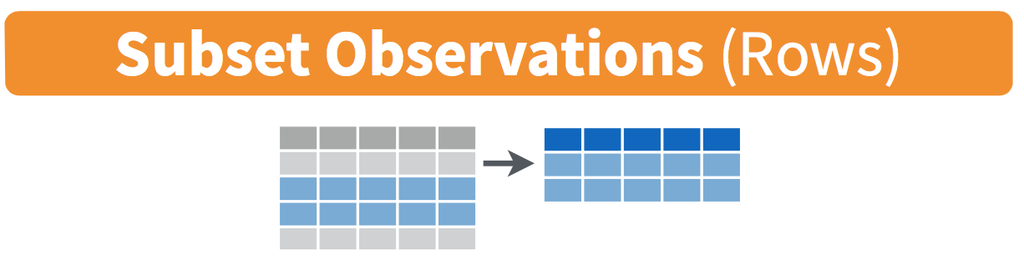

```r
penguins %>%
  filter(species == "Adelie")
```

| species | island | bill_length_mm | bill_depth_mm | flipper_length_mm | body_mass_g | sex | year |
| --- | --- | --- | --- | --- | --- | --- | --- |
| Adelie | Torgersen | 39.1 | 18.7 | 181 | 3750 | male | 2007 |
| Adelie | Torgersen | 39.5 | 17.4 | 186 | 3800 | female | 2007 |
| Adelie | Torgersen | 40.3 | 18.0 | 195 | 3250 | female | 2007 |
| Adelie | Torgersen | NA | NA | NA | NA | NA | 2007 |
| Adelie | Torgersen | 36.7 | 19.3 | 193 | 3450 | female | 2007 |
| Adelie | Torgersen | 39.3 | 20.6 | 190 | 3650 | male | 2007 |
| Adelie | Torgersen | 38.9 | 17.8 | 181 | 3625 | female | 2007 |
| Adelie | Torgersen | 39.2 | 19.6 | 195 | 4675 | male | 2007 |
| Adelie | Torgersen | 34.1 | 18.1 | 193 | 3475 | NA | 2007 |
| Adelie | Torgersen | 42.0 | 20.2 | 190 | 4250 | NA | 2007 |

[output cut: 142 more lines]

```r
penguins %>%
  filter(species == "Adelie" & island != "Torgersen")
```

| species | island | bill_length_mm | bill_depth_mm | flipper_length_mm | body_mass_g | sex | year |
| --- | --- | --- | --- | --- | --- | --- | --- |
| Adelie | Biscoe | 37.8 | 18.3 | 174 | 3400 | female | 2007 |
| Adelie | Biscoe | 37.7 | 18.7 | 180 | 3600 | male | 2007 |
| Adelie | Biscoe | 35.9 | 19.2 | 189 | 3800 | female | 2007 |
| Adelie | Biscoe | 38.2 | 18.1 | 185 | 3950 | male | 2007 |
| Adelie | Biscoe | 38.8 | 17.2 | 180 | 3800 | male | 2007 |
| Adelie | Biscoe | 35.3 | 18.9 | 187 | 3800 | female | 2007 |
| Adelie | Biscoe | 40.6 | 18.6 | 183 | 3550 | male | 2007 |
| Adelie | Biscoe | 40.5 | 17.9 | 187 | 3200 | female | 2007 |
| Adelie | Biscoe | 37.9 | 18.6 | 172 | 3150 | female | 2007 |
| Adelie | Biscoe | 40.5 | 18.9 | 180 | 3950 | male | 2007 |

[output cut: 90 more lines]

You can use other operators beyond just the `==` operator that tests for equality:

- `>` corresponds to “greater than”
- `<` corresponds to “less than”
- `>=` corresponds to “greater than or equal to”
- `<=` corresponds to “less than or equal to”
- `!=` corresponds to “not equal to.” The `!` is used in many programming languages to indicate “not.”

[`&`](https://rdrr.io/r/base/Logic.html) is “and”, [`|`](https://rdrr.io/r/base/Logic.html) is “or”, and [`!`](https://rdrr.io/r/base/Logic.html) is “not”.

TASK: Adelie but not from Torgersen

TASK Adelie or Gentto

|

```r
penguins %>%
  filter(species == "Adelie" | species == "Gentoo")
```

| species | island | bill_length_mm | bill_depth_mm | flipper_length_mm | body_mass_g | sex | year |
| --- | --- | --- | --- | --- | --- | --- | --- |
| Adelie | Torgersen | 39.1 | 18.7 | 181 | 3750 | male | 2007 |
| Adelie | Torgersen | 39.5 | 17.4 | 186 | 3800 | female | 2007 |
| Adelie | Torgersen | 40.3 | 18.0 | 195 | 3250 | female | 2007 |
| Adelie | Torgersen | NA | NA | NA | NA | NA | 2007 |
| Adelie | Torgersen | 36.7 | 19.3 | 193 | 3450 | female | 2007 |
| Adelie | Torgersen | 39.3 | 20.6 | 190 | 3650 | male | 2007 |
| Adelie | Torgersen | 38.9 | 17.8 | 181 | 3625 | female | 2007 |
| Adelie | Torgersen | 39.2 | 19.6 | 195 | 4675 | male | 2007 |
| Adelie | Torgersen | 34.1 | 18.1 | 193 | 3475 | NA | 2007 |
| Adelie | Torgersen | 42.0 | 20.2 | 190 | 4250 | NA | 2007 |

[output cut: 266 more lines]

Another way, using %in%

```r
penguins %>%
  filter(species %in% c("Adelie", "Gentoo"))
```

| species | island | bill_length_mm | bill_depth_mm | flipper_length_mm | body_mass_g | sex | year |
| --- | --- | --- | --- | --- | --- | --- | --- |
| Adelie | Torgersen | 39.1 | 18.7 | 181 | 3750 | male | 2007 |
| Adelie | Torgersen | 39.5 | 17.4 | 186 | 3800 | female | 2007 |
| Adelie | Torgersen | 40.3 | 18.0 | 195 | 3250 | female | 2007 |
| Adelie | Torgersen | NA | NA | NA | NA | NA | 2007 |
| Adelie | Torgersen | 36.7 | 19.3 | 193 | 3450 | female | 2007 |
| Adelie | Torgersen | 39.3 | 20.6 | 190 | 3650 | male | 2007 |
| Adelie | Torgersen | 38.9 | 17.8 | 181 | 3625 | female | 2007 |
| Adelie | Torgersen | 39.2 | 19.6 | 195 | 4675 | male | 2007 |
| Adelie | Torgersen | 34.1 | 18.1 | 193 | 3475 | NA | 2007 |
| Adelie | Torgersen | 42.0 | 20.2 | 190 | 4250 | NA | 2007 |

[output cut: 266 more lines]

TASK

Filter all penguins from Torgersen weighing more than 3500g

#### Mutate

Create new variables

bill_ratio = bill_length_mm / bill_depth_mm

```r
penguins %>%
  mutate(bill_ratio = bill_length_mm / bill_depth_mm)
```

| species | island | bill_length_mm | bill_depth_mm | flipper_length_mm | body_mass_g | sex | year | bill_ratio |
| --- | --- | --- | --- | --- | --- | --- | --- | --- |
| Adelie | Torgersen | 39.1 | 18.7 | 181 | 3750 | male | 2007 | 2.090909 |
| Adelie | Torgersen | 39.5 | 17.4 | 186 | 3800 | female | 2007 | 2.270115 |
| Adelie | Torgersen | 40.3 | 18.0 | 195 | 3250 | female | 2007 | 2.238889 |
| Adelie | Torgersen | NA | NA | NA | NA | NA | 2007 | NA |
| Adelie | Torgersen | 36.7 | 19.3 | 193 | 3450 | female | 2007 | 1.901554 |
| Adelie | Torgersen | 39.3 | 20.6 | 190 | 3650 | male | 2007 | 1.907767 |
| Adelie | Torgersen | 38.9 | 17.8 | 181 | 3625 | female | 2007 | 2.185393 |
| Adelie | Torgersen | 39.2 | 19.6 | 195 | 4675 | male | 2007 | 2.000000 |
| Adelie | Torgersen | 34.1 | 18.1 | 193 | 3475 | NA | 2007 | 1.883978 |
| Adelie | Torgersen | 42.0 | 20.2 | 190 | 4250 | NA | 2007 | 2.079208 |

[output cut: 334 more lines]

Relocate after island column

```r
penguins %>%
  mutate(bill_ratio = bill_length_mm / bill_depth_mm) %>%
  relocate(bill_ratio, .after = island)
```

| species | island | bill_ratio | bill_length_mm | bill_depth_mm | flipper_length_mm | body_mass_g | sex | year |
| --- | --- | --- | --- | --- | --- | --- | --- | --- |
| Adelie | Torgersen | 2.090909 | 39.1 | 18.7 | 181 | 3750 | male | 2007 |
| Adelie | Torgersen | 2.270115 | 39.5 | 17.4 | 186 | 3800 | female | 2007 |
| Adelie | Torgersen | 2.238889 | 40.3 | 18.0 | 195 | 3250 | female | 2007 |
| Adelie | Torgersen | NA | NA | NA | NA | NA | NA | 2007 |
| Adelie | Torgersen | 1.901554 | 36.7 | 19.3 | 193 | 3450 | female | 2007 |
| Adelie | Torgersen | 1.907767 | 39.3 | 20.6 | 190 | 3650 | male | 2007 |
| Adelie | Torgersen | 2.185393 | 38.9 | 17.8 | 181 | 3625 | female | 2007 |
| Adelie | Torgersen | 2.000000 | 39.2 | 19.6 | 195 | 4675 | male | 2007 |
| Adelie | Torgersen | 1.883978 | 34.1 | 18.1 | 193 | 3475 | NA | 2007 |
| Adelie | Torgersen | 2.079208 | 42.0 | 20.2 | 190 | 4250 | NA | 2007 |

[output cut: 334 more lines]

TASK

```r
penguins %>%
  mutate(body_mass_k = log10(body_mass_g))
```

| species | island | bill_length_mm | bill_depth_mm | flipper_length_mm | body_mass_g | sex | year | body_mass_k |
| --- | --- | --- | --- | --- | --- | --- | --- | --- |
| Adelie | Torgersen | 39.1 | 18.7 | 181 | 3750 | male | 2007 | 3.574031 |
| Adelie | Torgersen | 39.5 | 17.4 | 186 | 3800 | female | 2007 | 3.579784 |
| Adelie | Torgersen | 40.3 | 18.0 | 195 | 3250 | female | 2007 | 3.511883 |
| Adelie | Torgersen | NA | NA | NA | NA | NA | 2007 | NA |
| Adelie | Torgersen | 36.7 | 19.3 | 193 | 3450 | female | 2007 | 3.537819 |
| Adelie | Torgersen | 39.3 | 20.6 | 190 | 3650 | male | 2007 | 3.562293 |
| Adelie | Torgersen | 38.9 | 17.8 | 181 | 3625 | female | 2007 | 3.559308 |
| Adelie | Torgersen | 39.2 | 19.6 | 195 | 4675 | male | 2007 | 3.669782 |
| Adelie | Torgersen | 34.1 | 18.1 | 193 | 3475 | NA | 2007 | 3.540955 |
| Adelie | Torgersen | 42.0 | 20.2 | 190 | 4250 | NA | 2007 | 3.628389 |

[output cut: 334 more lines]

#### Grouping and summarizing data

calculate the mean body_mass_g by specie

```r
penguins %>%
  group_by(species) %>%
  # now I will remove the NAs values
  drop_na() %>%
  # and now the summary of the variable
  summarise(n = n(),
            mean = mean(body_mass_g),
            sd = sd(body_mass_g),
            max = max(body_mass_g),
            min = min(body_mass_g)) %>%
  mutate(across(where(is.numeric), ~ round(., 1)))
```

| species | n | mean | sd | max | min |
| --- | --- | --- | --- | --- | --- |
| Adelie | 146 | 3706.2 | 458.6 | 4775 | 2850 |
| Chinstrap | 68 | 3733.1 | 384.3 | 4800 | 2700 |
| Gentoo | 119 | 5092.4 | 501.5 | 6300 | 3950 |

Dealing with NAs

na.rm = T

drop_na()

```r
penguins %>%
  group_by(species) %>%
  drop_na() %>%
  summarise(median = median(flipper_length_mm),
            sd = sd(flipper_length_mm)) %>%
  mutate(across(where(is.numeric), ~ round(., 1)))
```

| species | median | sd |
| --- | --- | --- |
| Adelie | 190 | 6.5 |
| Chinstrap | 196 | 7.1 |
| Gentoo | 216 | 6.6 |

## Wide vs long format

### Load data

```r
gap_wide <- read_csv("https://bit.ly/gapminder-rsu")
```

### Explore the data

How many variables?

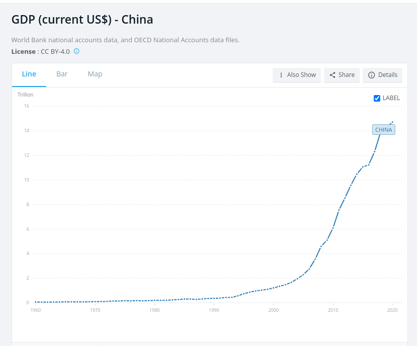

Filter China

How to plot ?

### Wide vs long

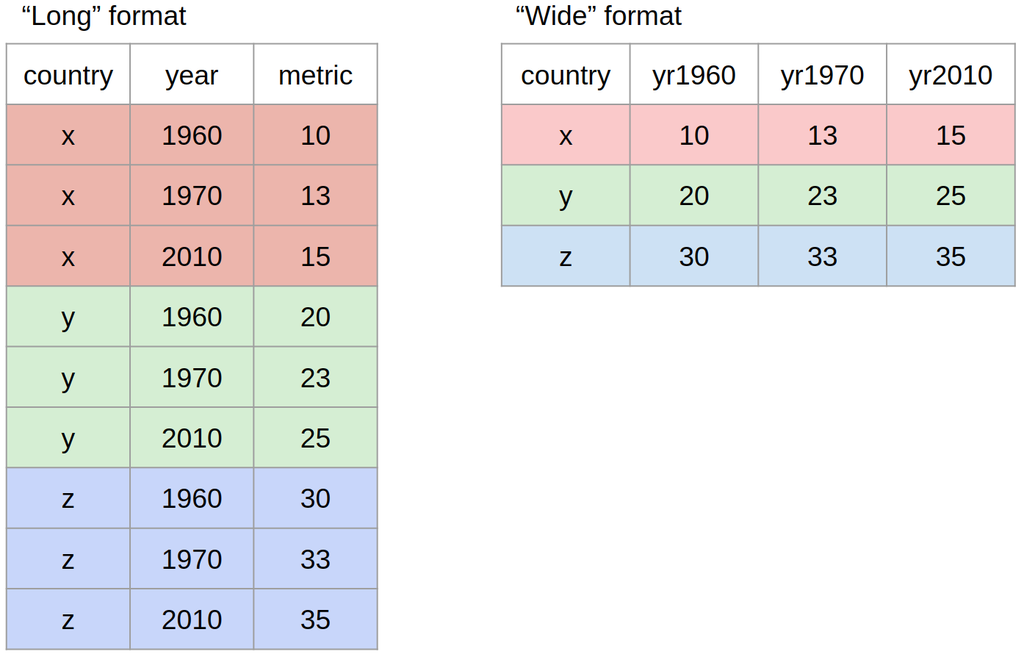

- Wide data is for humans
- Long data is for computers

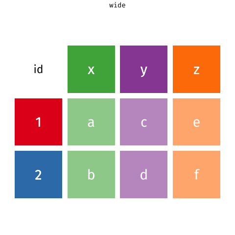

#### Wide to long

gdp

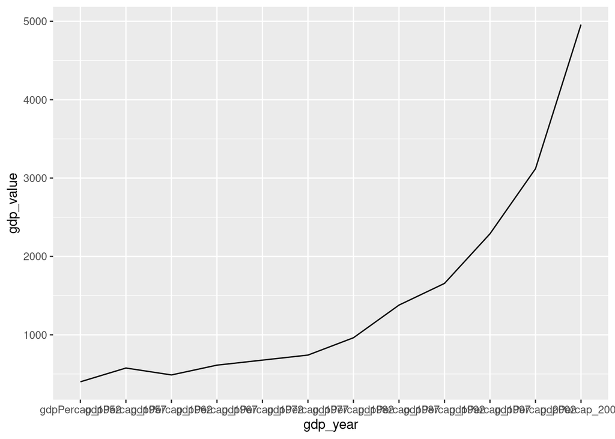

```r
gap_wide %>%
  select(continent:gdpPercap_2007) %>%
  pivot_longer(cols = gdpPercap_1952:gdpPercap_2007,
               names_to = "gdp_year",
               values_to = "gdp_value") %>%
  filter(country == "China") %>%
  ggplot(aes(x = gdp_year,
             y = gdp_value,
             group = country)) +
  geom_line()
```

try to plot

Filter only China

Conects the points

Filter Europe and conects the points

## Split-apply-combine

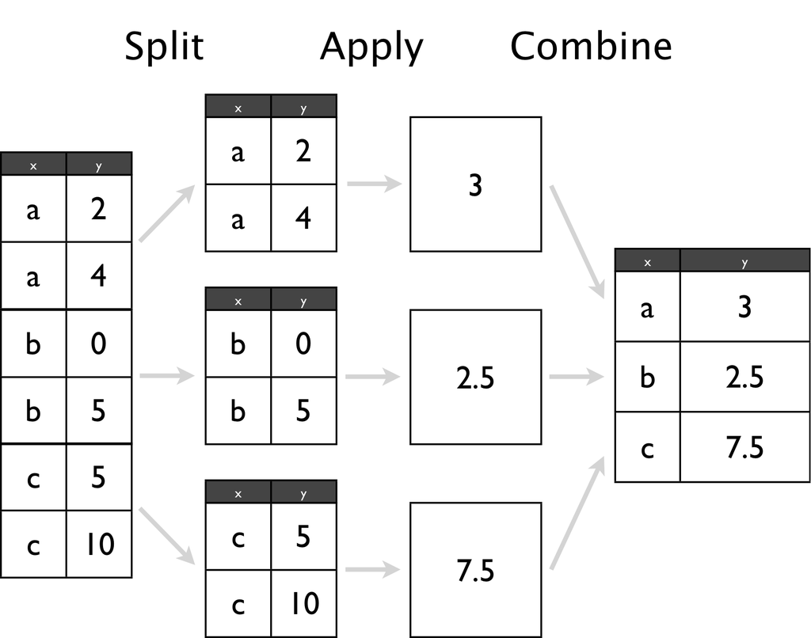

Now, we will use the long gapminder dataset

### Question: how has GDP per continent evolved per year?

```r
gapminder %>%
  filter(year == 2007) %>%
  group_by(continent) %>%
  summarise(mean_gdp = mean(gdpPercap),
            mean_pop = mean(pop),
            mean_lifeexp = mean(lifeExp),
            n = n())
```

| continent | mean_gdp | mean_pop | mean_lifeexp | n |
| --- | --- | --- | --- | --- |
| Africa | 3089.033 | 17875763 | 54.80604 | 52 |
| Americas | 11003.032 | 35954847 | 73.60812 | 25 |
| Asia | 12473.027 | 115513752 | 70.72848 | 33 |
| Europe | 25054.482 | 19536618 | 77.64860 | 30 |
| Oceania | 29810.188 | 12274974 | 80.71950 | 2 |

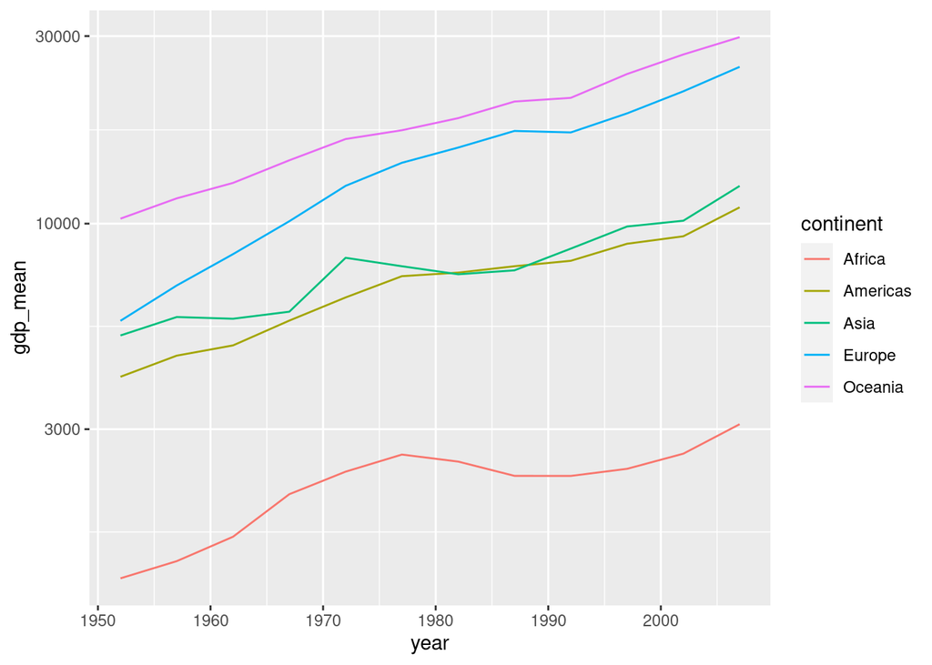

```r
gapminder %>%
  group_by(continent, year) %>%
  summarise(gdp_mean = mean(gdpPercap)) %>%
  ggplot(aes(x = year,
             y = gdp_mean,
             color = continent)) +
  geom_line() +
  scale_y_log10()
```

### Question: how has POPULATION per continent evolved per year?

Hint: Try log10

## Example: Vaccinations Latvia

Homework: See [<https://github.com/owid/covid-19-data/tree/master/public/data/vaccinations>](https://github.com/owid/covid-19-data/tree/master/public/data/vaccinations)

```r
covid_vac <- read_csv("https://github.com/owid/covid-19-data/raw/master/public/data/vaccinations/vaccinations.csv")
```

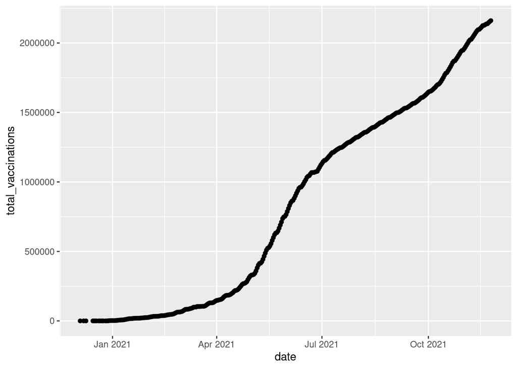

```r
covid_vac %>%
  filter(location == "Latvia") %>%
  ggplot(aes(x = date,
             y = total_vaccinations)) +
  geom_point()
```